# 2016 Suicides vs. Happines Rankings

# Question

**Does the World Happiness Report have any correlation to country suicide rates?**

Using two data sets, Suicides Per 100,000 and 2015/2016 World Happiness Report, we will look to see if there is a connection between the “happiest” countries and amount of suicides. The World Happiness Report uses economic and social development to determine happiness rank. The report negates the fact there is more to happiness than policy and economic well-being. With the help of data collected by the World Health Organization, a more in-depth analysis can be made about happiness per country.

### Male to Female Ratio

First, let’s take a look at the ratio of male to female suicides per region.

| Region | Male | Female | Year |
| --- | --- | --- | --- |
| Australia and New Zealand | 17.4 | 6.1 | 2016 |
| Central and Eastern Europe | 19.4 | 4.02 | 2016 |
| Latin America and Caribbean | 14.2 | 3.76 | 2016 |
| Middle East and Northern Africa | 6.25 | 2.44 | 2016 |
| North America | 18.1 | 6.1 | 2016 |
| Southern Asia | 12.3 | 7.07 | 2016 |
| Southeastern Asia | 9.56 | 4.4 | 2016 |
| Sub-Saharan Africa | 17 | 7.31 | 2016 |
| Western Europe | 14.4 | 5.05 | 2016 |

### Happiness Rankings and Suicides

By rearranging the *HappinessRank* column into numerical order and taking only the top 25 and the bottom 25 ranked countries, the graphs do not look much different. The top 25 ranked countries have a mean of 9.70 suicides per 100000 while the bottom 25 have 11.6 suicides per 100000.

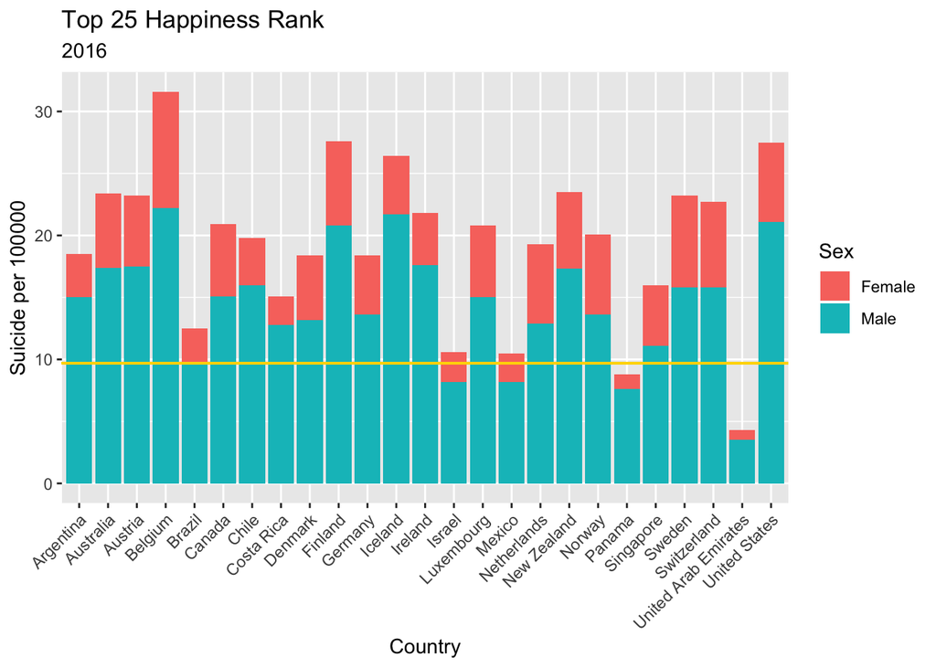

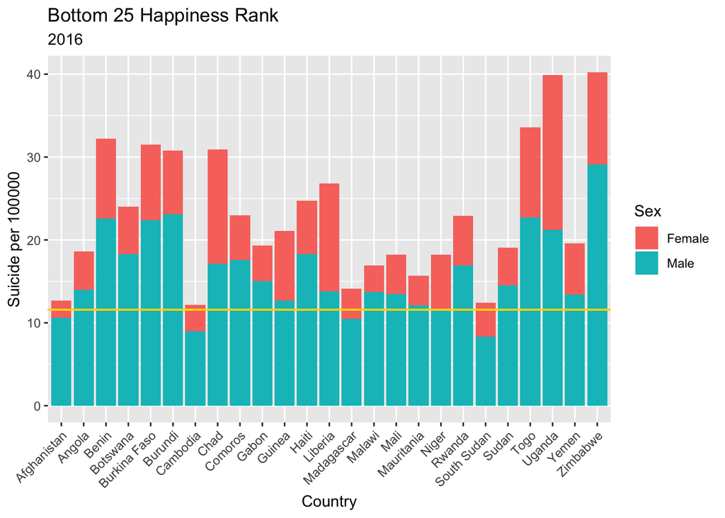

### Regions, Ranks, and Suicides

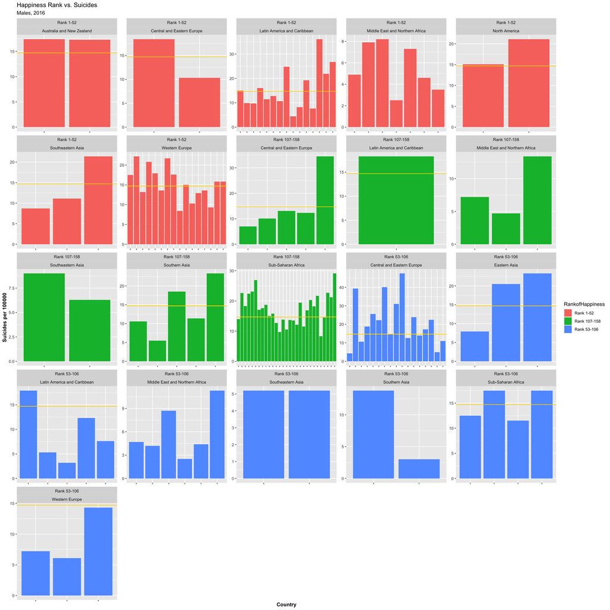

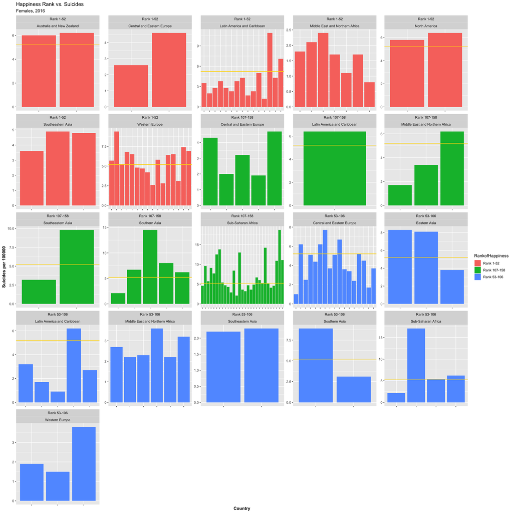